# HPC Prediction -- Supervised Learning Applications

Yazid Hoblos

2022-11-12

```r
knitr :: opts_chunk$set(warning=FALSE)
```

```r
knitr::opts_chunk$set(error=TRUE)
```

This dataset is a microarray that consists of non-normalized genes expression for 357 patients, extensively curated from 30.000 studies from the Gene Expression Omnibus (GEO). The cases fall within 1 of 2 classes : normal/HCC (Hepatocellular Carcinoma).

```r
library(dplyr)
library(leaps)
library(MASS)
library(caret)
```

```r
library(ggplot2)
library(pROC)
df = read.csv("Liver cancer.csv")
View(df)
```

A quick inspection of the data shows that the numbers of normal and HCC patients are almost the same.

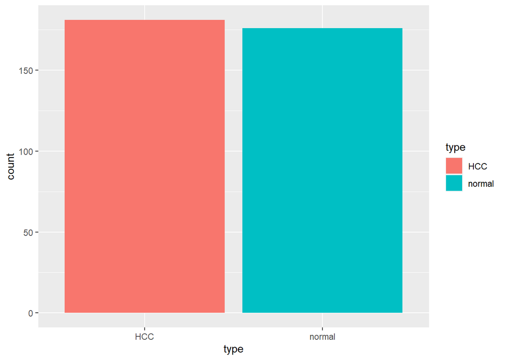

```r
df %>% ggplot()+
  geom_bar(aes(type,fill=type))
```

I. Normalization

#Using the standardization technique

```r
df_S = df
df_S[3:ncol(df_S)] <-  scale(df_S[3:ncol(df_S)],center = TRUE, scale = TRUE)
```

The regular standardization resulting in a mean of 0 and standard deviation of 1 is first considered.

#Using the max-min technique

```r
df_M = df[1:2]
normalize <- function(x, na.rm = TRUE) {
    return((x- min(x)) /(max(x)-min(x)))
}

df_M [3:ncol(df)] = lapply(df[3:ncol(df)], normalize)
```

The min-max technique will make all values between 0 and 1, in other words, it suppresses all the values towards the mean and it is not very efficient when dealing with outliers. The robust scaling algorithm offers an alternative to better deal with outliers without losing them.

#Using the robust scaling technique

```r
df_R = df[1:2]
robust_scalar<- function(x){(x- median(x)) /(quantile(x,probs = .75)-quantile(x,probs = .25))}
df_R[3:ncol(df)] = lapply(df[3:ncol(df)], robust_scalar)
```

The summaries below show the changes in the data patterns after the application of the normalization techniques (mean=0,median=0,min=0 for df_S,df_R,and df_M respectively). Further investigation of the effects of these different types of normalization will be done in the next section.

```r
summary(df[1:10])
```

```
##    samples              type             X1007_s_at        X1053_at
##  Length:357         Length:357         Min.   : 5.440   Min.   :3.208
##  Class :character   Class :character   1st Qu.: 6.459   1st Qu.:4.023
##  Mode  :character   Mode  :character   Median : 6.775   Median :4.246
##                                        Mean   : 6.920   Mean   :4.365
##                                        3rd Qu.: 7.142   3rd Qu.:4.603
##                                        Max.   :10.204   Max.   :7.118
##     X117_at         X121_at        X1255_g_at       X1294_at
##  Min.   :3.350   Min.   :4.843   Min.   :2.927   Min.   :4.408
##  1st Qu.:3.757   1st Qu.:5.471   1st Qu.:3.114   1st Qu.:5.692
##  Median :3.899   Median :5.664   Median :3.184   Median :6.014
##  Mean   :3.998   Mean   :5.676   Mean   :3.197   Mean   :5.945
##  3rd Qu.:4.126   3rd Qu.:5.885   3rd Qu.:3.270   3rd Qu.:6.240
##  Max.   :8.452   Max.   :6.421   Max.   :3.624   Max.   :7.322
##     X1316_at        X1320_at
##  Min.   :3.213   Min.   :3.202
##  1st Qu.:3.651   1st Qu.:3.433
##  Median :3.767   Median :3.527
##  Mean   :3.784   Mean   :3.536
##  3rd Qu.:3.906   3rd Qu.:3.606
##  Max.   :4.617   Max.   :4.123
```

```r
summary(df_S[1:10])
```

```
##    samples              type             X1007_s_at         X1053_at
##  Length:357         Length:357         Min.   :-1.8603   Min.   :-2.2365
##  Class :character   Class :character   1st Qu.:-0.5793   1st Qu.:-0.6615
##  Mode  :character   Mode  :character   Median :-0.1816   Median :-0.2290
##                                        Mean   : 0.0000   Mean   : 0.0000
##                                        3rd Qu.: 0.2792   3rd Qu.: 0.4609
##                                        Max.   : 4.1283   Max.   : 5.3257
##     X117_at           X121_at           X1255_g_at         X1294_at
##  Min.   :-1.4149   Min.   :-2.56970   Min.   :-2.2969   Min.   :-3.3372
##  1st Qu.:-0.5257   1st Qu.:-0.63443   1st Qu.:-0.7070   1st Qu.:-0.5489
##  Median :-0.2161   Median :-0.03856   Median :-0.1082   Median : 0.1504
##  Mean   : 0.0000   Mean   : 0.00000   Mean   : 0.0000   Mean   : 0.0000
##  3rd Qu.: 0.2790   3rd Qu.: 0.64328   3rd Qu.: 0.6212   3rd Qu.: 0.6420
##  Max.   : 9.7233   Max.   : 2.29838   Max.   : 3.6395   Max.   : 2.9905
##     X1316_at           X1320_at
##  Min.   :-2.55861   Min.   :-2.28014
##  1st Qu.:-0.59945   1st Qu.:-0.70063
##  Median :-0.07671   Median :-0.06249
##  Mean   : 0.00000   Mean   : 0.00000
##  3rd Qu.: 0.54408   3rd Qu.: 0.48107
##  Max.   : 3.72608   Max.   : 4.01390
```

```r
summary(df_M[1:10])
```

```
##    samples              type             X1007_s_at        X1053_at
##  Length:357         Length:357         Min.   :0.0000   Min.   :0.0000
##  Class :character   Class :character   1st Qu.:0.2139   1st Qu.:0.2083
##  Mode  :character   Mode  :character   Median :0.2803   Median :0.2655
##                                        Mean   :0.3106   Mean   :0.2957
##                                        3rd Qu.:0.3573   3rd Qu.:0.3567
##                                        Max.   :1.0000   Max.   :1.0000
##     X117_at           X121_at         X1255_g_at        X1294_at
##  Min.   :0.00000   Min.   :0.0000   Min.   :0.0000   Min.   :0.0000
##  1st Qu.:0.07983   1st Qu.:0.3975   1st Qu.:0.2678   1st Qu.:0.4406
##  Median :0.10763   Median :0.5199   Median :0.3687   Median :0.5512
##  Mean   :0.12703   Mean   :0.5279   Mean   :0.3869   Mean   :0.5274
##  3rd Qu.:0.15208   3rd Qu.:0.6600   3rd Qu.:0.4916   3rd Qu.:0.6289
##  Max.   :1.00000   Max.   :1.0000   Max.   :1.0000   Max.   :1.0000
##     X1316_at         X1320_at
##  Min.   :0.0000   Min.   :0.0000
##  1st Qu.:0.3117   1st Qu.:0.2510
##  Median :0.3949   Median :0.3523
##  Mean   :0.4071   Mean   :0.3623
##  3rd Qu.:0.4937   3rd Qu.:0.4387
##  Max.   :1.0000   Max.   :1.0000
```

```r
summary(df_R[1:10])
```

```
##    samples              type             X1007_s_at         X1053_at
##  Length:357         Length:357         Min.   :-1.9555   Min.   :-1.7886
##  Class :character   Class :character   1st Qu.:-0.4633   1st Qu.:-0.3853
##  Mode  :character   Mode  :character   Median : 0.0000   Median : 0.0000
##                                        Mean   : 0.2115   Mean   : 0.2040
##                                        3rd Qu.: 0.5367   3rd Qu.: 0.6147
##                                        Max.   : 5.0205   Max.   : 4.9492
##     X117_at           X121_at           X1255_g_at          X1294_at
##  Min.   :-1.4898   Min.   :-1.98098   Min.   :-1.64789   Min.   :-2.9284
##  1st Qu.:-0.3848   1st Qu.:-0.46636   1st Qu.:-0.45085   1st Qu.:-0.5872
##  Median : 0.0000   Median : 0.00000   Median : 0.00000   Median : 0.0000
##  Mean   : 0.2685   Mean   : 0.03018   Mean   : 0.08144   Mean   :-0.1263
##  3rd Qu.: 0.6152   3rd Qu.: 0.53364   3rd Qu.: 0.54915   3rd Qu.: 0.4128
##  Max.   :12.3517   Max.   : 1.82900   Max.   : 2.82170   Max.   : 2.3848
##     X1316_at           X1320_at
##  Min.   :-2.17039   Min.   :-1.87667
##  1st Qu.:-0.45713   1st Qu.:-0.54002
##  Median : 0.00000   Median : 0.00000
##  Mean   : 0.06709   Mean   : 0.05288
##  3rd Qu.: 0.54287   3rd Qu.: 0.45998
##  Max.   : 3.32549   Max.   : 3.44962
```

2. Genes selection & Logistic regression application

Genes will be selected based on their variance distribution, based on the fact that the considered cancer is expected to result in a deviated from normal expression for some genes. The set of genes with the highest variance will be selected first for inspection of potential correlations and patterns. To this end, the distribution of the variances and the effect of the different types of normalization on this distribution will be investigated.

Note that over the whole upcoming section var will refer to the overall variance, while var1 and var2 will refer to the variance over the HCC cases and normal cases respectively.

1. Using the original dataset

```r
var=var1=var2=c(0,0)
for(i in 3:ncol(df)){
  var[i] = var(df[,i]) #overall variance
  var1[i] = var(df[1:181,i]) #variance over HCC cases
  var2[i] = var(df[182:357,i]) #variance over normal patients
}
```

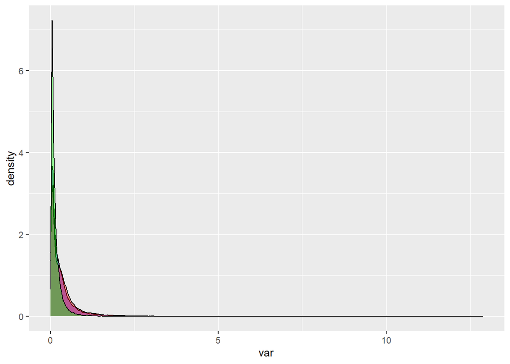

```r
v=cbind(var,var1,var2)
as.data.frame(v) %>% ggplot()+
  geom_density(aes(var),fill='blue',alpha=0.4)+
  geom_density(aes(var1),fill='red',alpha=0.4)+
  geom_density(aes(var2),fill='green',alpha=0.4)
```

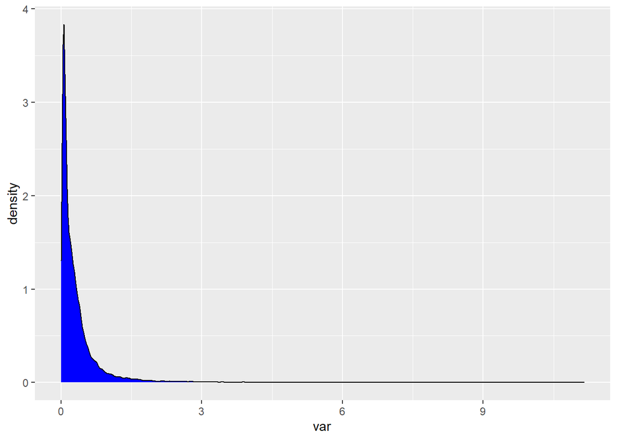

```r
as.data.frame(v) %>% ggplot()+
  geom_density(aes(var),fill='blue')
```

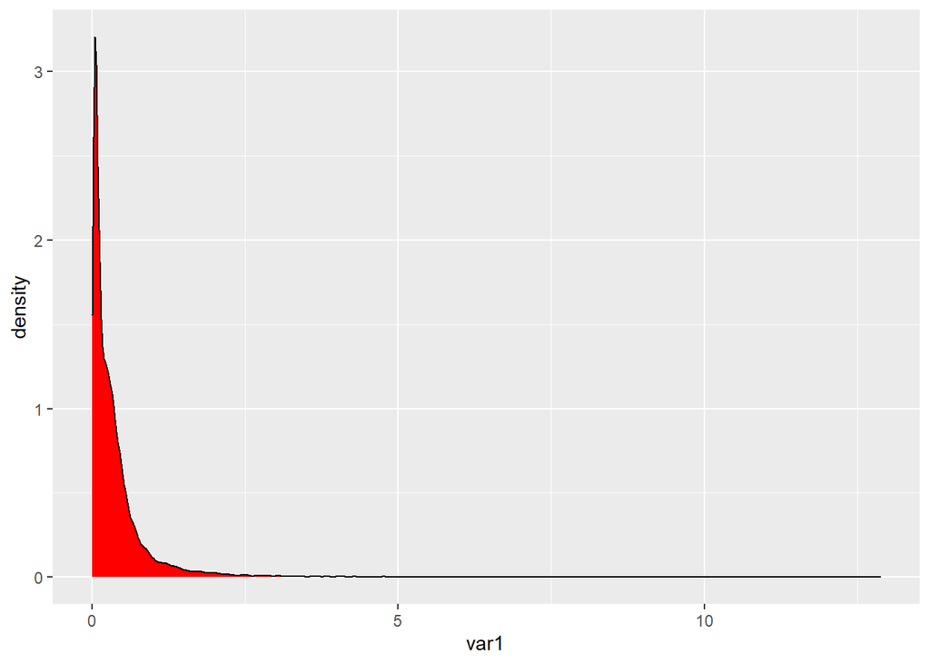

```r
as.data.frame(v) %>% ggplot()+
   geom_density(aes(var1),fill='red')
```

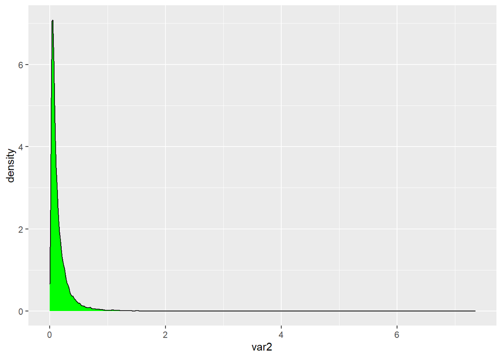

```r
as.data.frame(v) %>% ggplot()+
  geom_density(aes(var2),fill='green')
```

```r
max=0
for (i in var){
  if(i>max){
    max=i
  }
}
print(max)
```

```
## [1] 11.14694
```

It is not enough to only consider the overall variance, because as will be clarified with further examination some of the genes with high variance might be highly variating among both the normal and HCC cases, and thus their variance is not dependent on the HCC itself but on other factors that might be affecting some of both the normal and HCC cases. That is why it could be hypothesized that it is important to investigate the variance over the HCC cases and normal cases alone.

Generally speaking, normalizing the data (i.e roughly speaking scaling it to some common frame) is expected to allow for better understanding of the interrelations between the genes and the selection of the best genes to be included in the model. Which of the considered normalization techniques represent the optimal choice remains to be investigated.

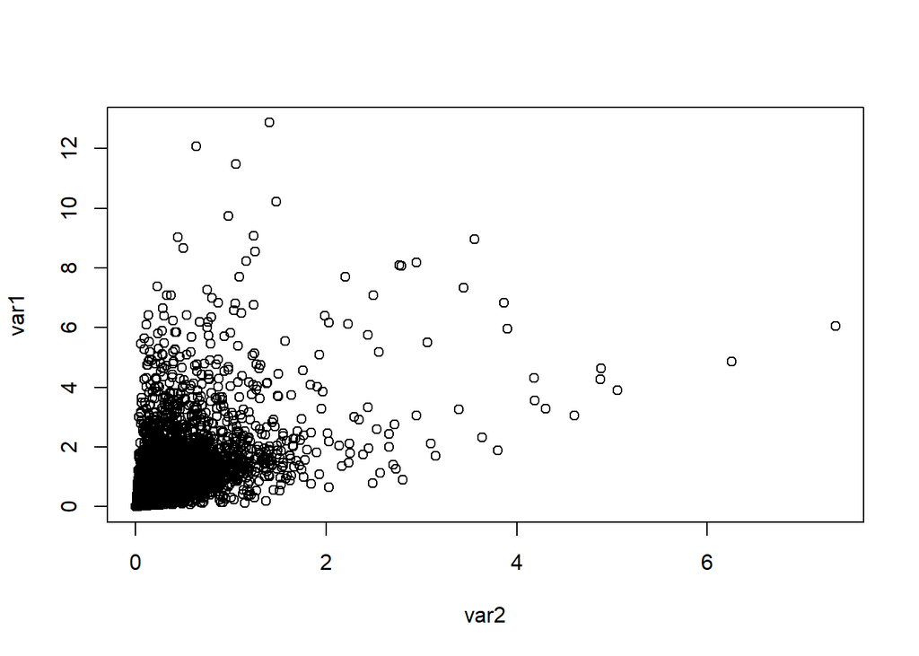

```r
plot(var1~var2)
```

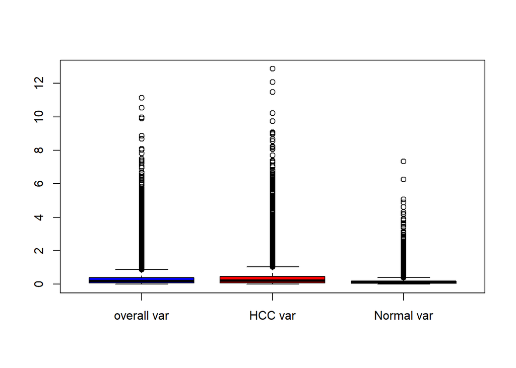

```r
boxplot(v[,1:3],col=c('blue','red','green'),names=c('overall var','HCC var', 'Normal var'))
```

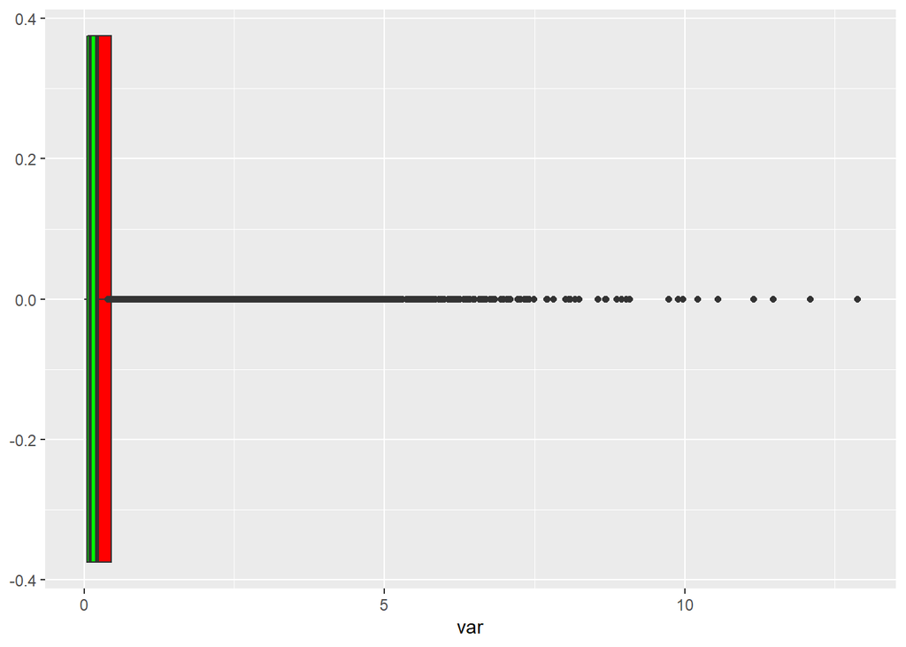

```r
as.data.frame(v) %>% ggplot()+
  geom_boxplot(aes(var),fill='blue')+
  geom_boxplot(aes(var1),fill='red')+
  geom_boxplot(aes(var2),fill='green')
```

The density plots show that the 3 variance patterns are quite similar, with most variance values between lying 0 and 1, and the max variance value is shown to be 11.14. Most of the genes expression are shown to have low variance across all cases, while some are shown to be highly expressed in the HCC cases only, and a handful of others are not as clearly distributed.

```r
count=0
for (i in 3:ncol(df)){
  if(var(df[i])>6){
    count=count+1
  }
}
count
```

```
## [1] 27
```

A simple approach for genes selection would be to consider the genes with overall high variance. 27 genes are found to have variance greater than 6, and examining these values shows that their variability majorly stems from the HCC cases majorly (check the values below), and not the normal cases, which reflects the fact that these are some of the genes whose expression is likely to be distorted in HCC patients. The high variation of the expression of these genes among the HCC cases might stem from the existence of different subtypes of HCC, or the fact that the considered cases might be in different stages of their cancer. Being able to find some genes with low variance among the HCC cases and the normal cases alone, but overall high variance is expected to offer better seperation. Those genes investigation will be left for later on.

```r
for (i in 3:ncol(df)){
  if(var(df[i])>6){
  print(colnames(df)[i])
  print(var[i])
  print(var1[i])
  print(var2[i])
  print("")
  }
}
```

```
## [1] "X1431_at"
## [1] 7.330133
## [1] 9.024342
## [1] 0.4418975
## [1] ""
## [1] "X1494_f_at"
## [1] 7.492426
## [1] 6.195658
## [1] 0.7576319
## [1] ""
## [1] "X202409_at"
## [1] 7.395604
## [1] 12.09018
## [1] 0.6397725
## [1] ""
```

[output cut: 120 more lines]

The 27 genes with variance > 6 will be taken into consideration, and a mutated dataset containing only them will be created.

```r
mut_df=df[1:2]
current=3
for (i in 3:ncol(df)){
  if(var(df[i])>6){
    mut_df=cbind(mut_df,df[,i])
    colnames(mut_df)[current]=colnames(df[i])
      current=current+1
  }
}
ncol(mut_df)
```

```
## [1] 29
```

The previous observation concerning the variability of the genes with highest variance being caused by the HCC cases majorly can be confirmed using the density plots, which also offers a better understanding of the variability of these genes.

One interesting pattern revealed by these plots, is that for most of the selected genes, the expression for the normal cases is highly concentrated is a small range of values (be it high or low), except for small disturbances preventing the almost perfect separation which would have been reached had it been the case that the expression of those genes for normal cases was completely bounded within a small range. This pattern can specially be seen in the 4th and 5th plots.

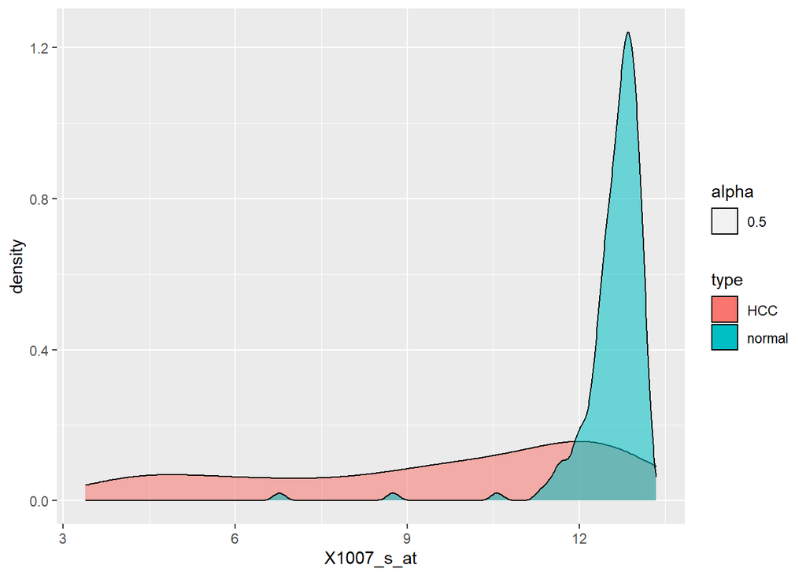

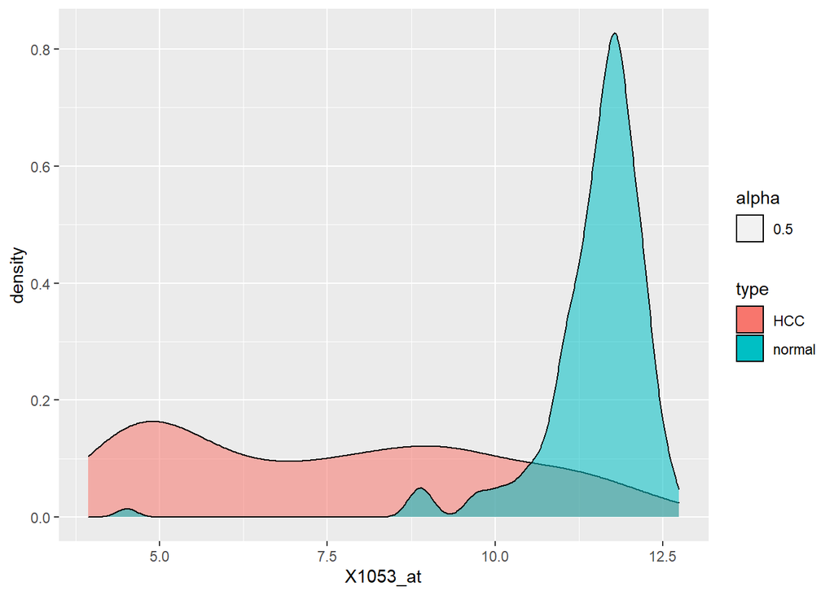

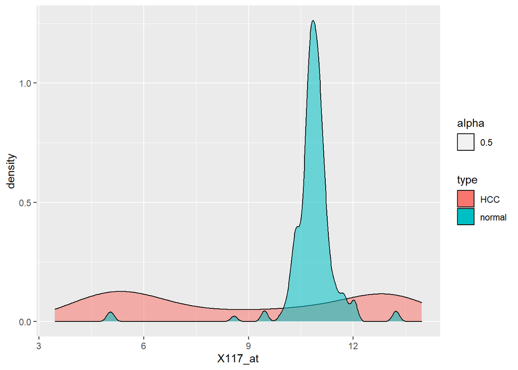

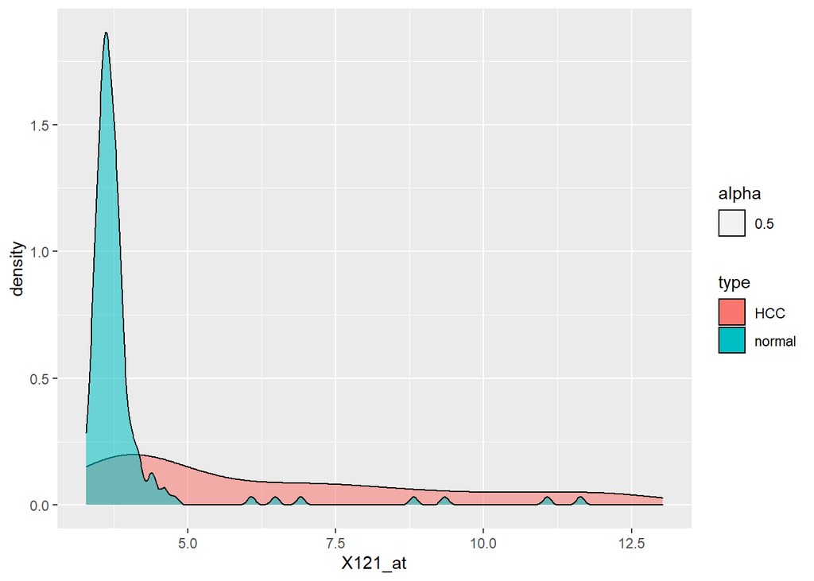

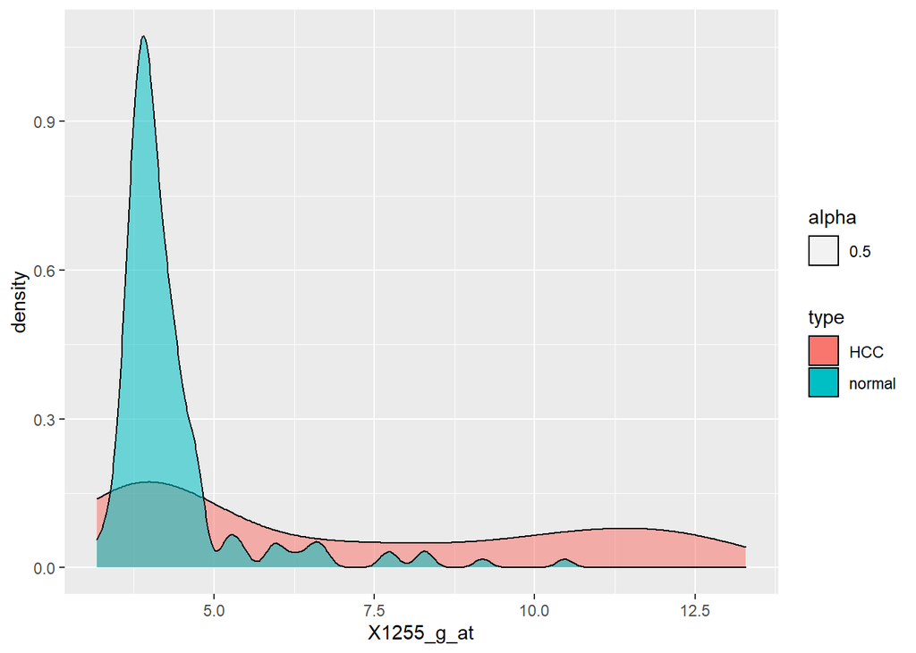

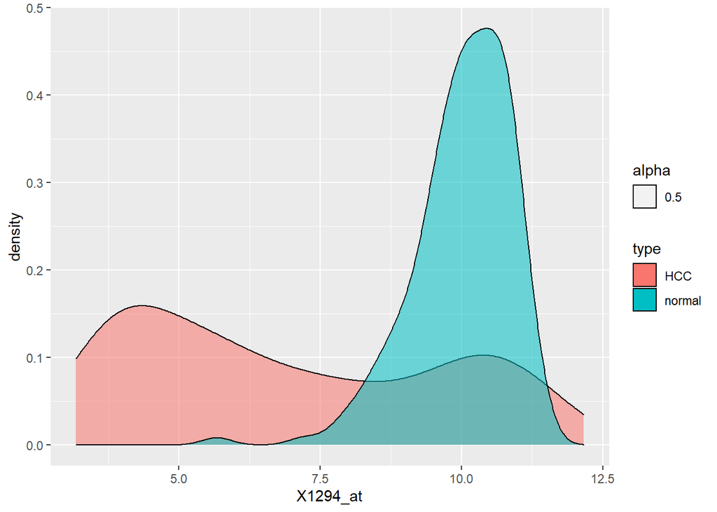

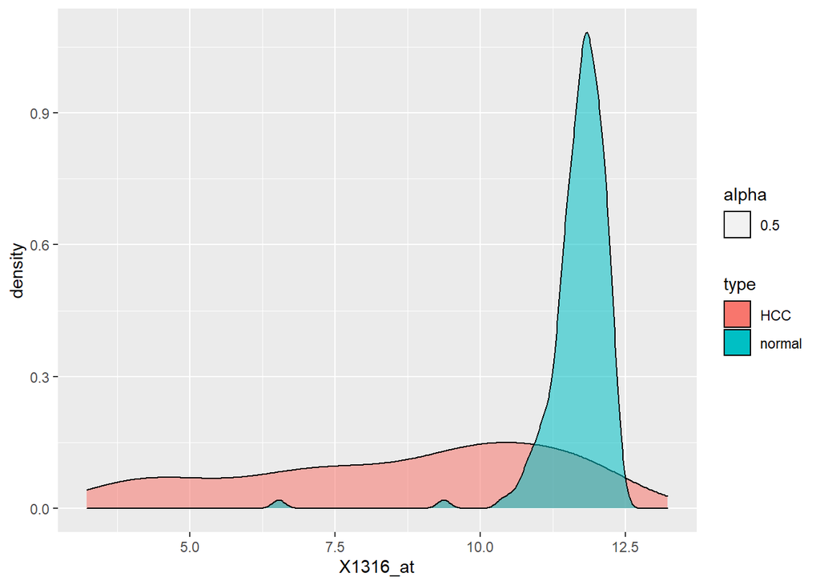

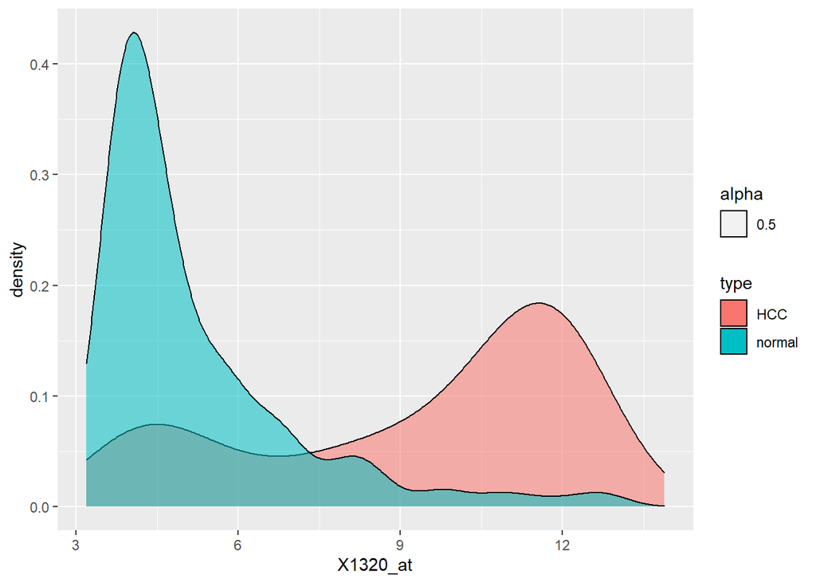

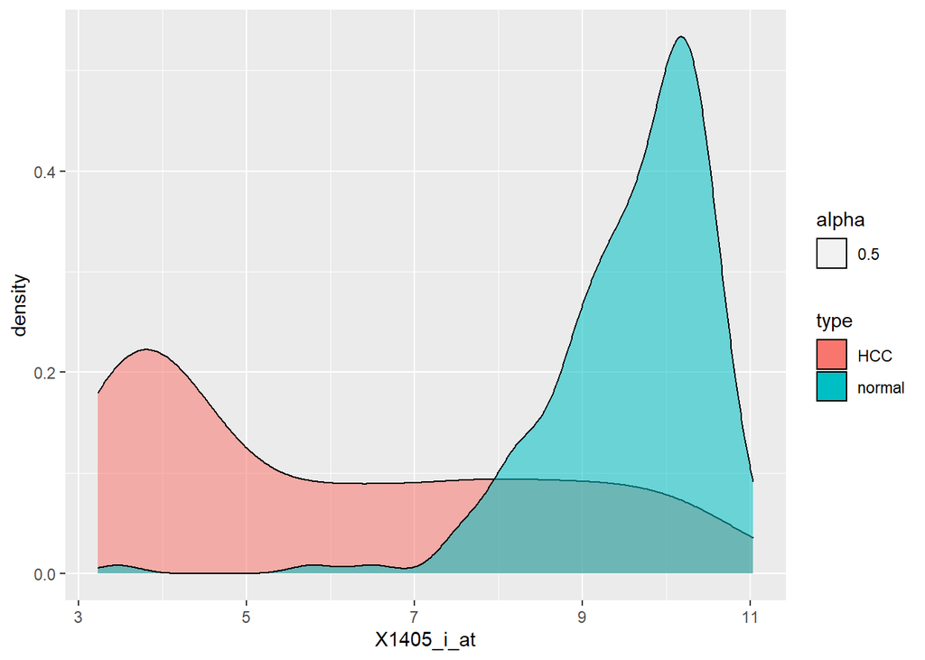

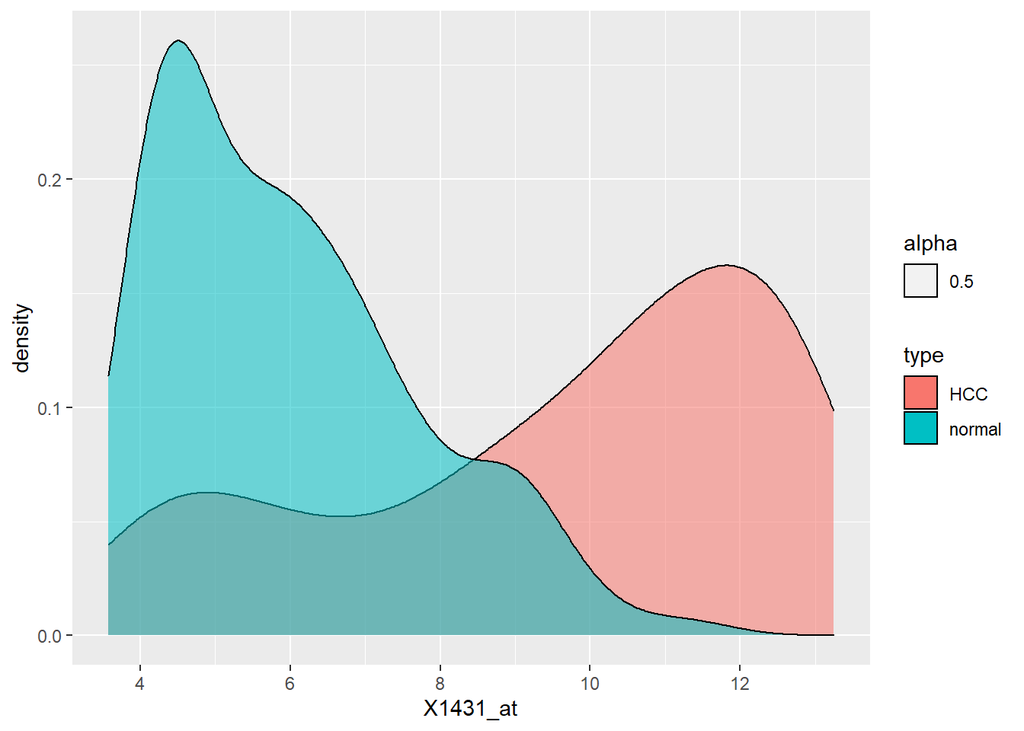

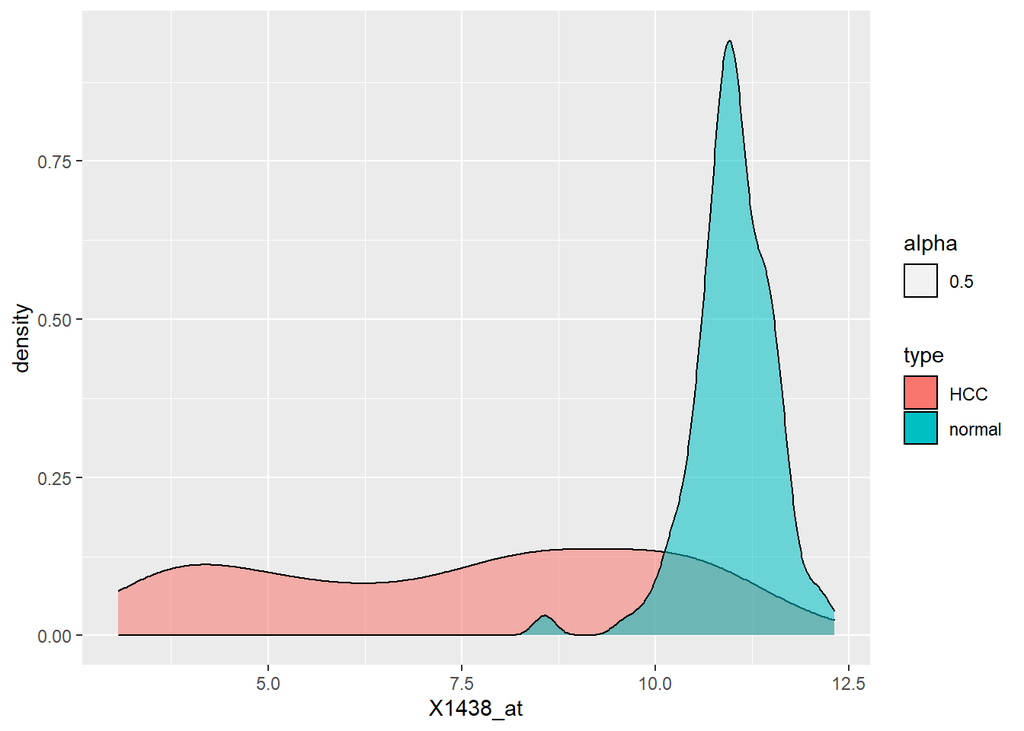

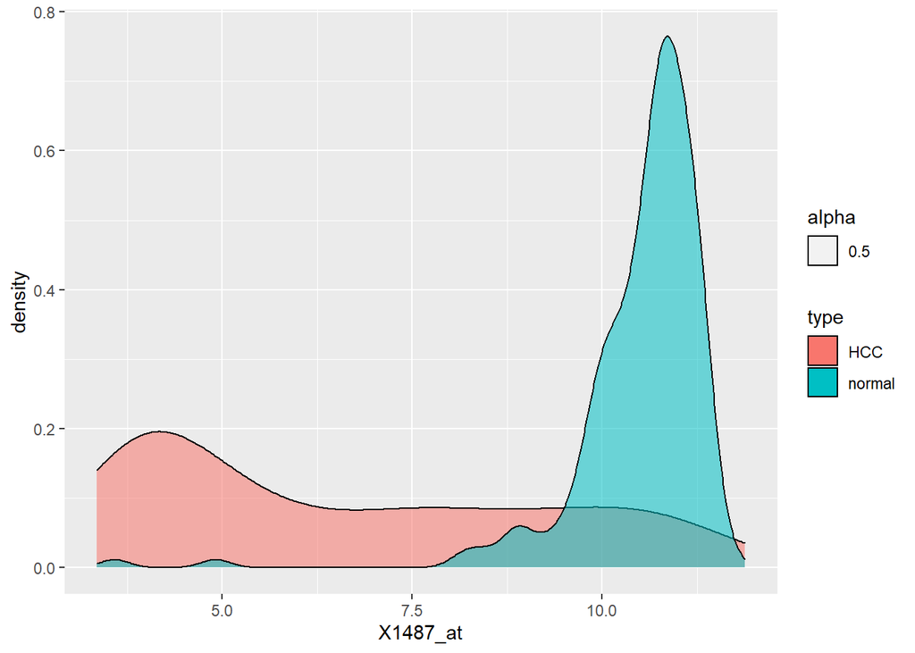

[15 more figures not shown]

```r
for(i in 3:29){
  print(mut_df %>% ggplot()+
   geom_density(aes(mut_df[,i],group=type,fill=type,alpha=0.5))+
    labs(y='density',x=colnames(df)[i]) )
}
```

Potential correlations between the selected genes are next considered. And it can be notices that linear and non-linear correlations exist. These correlations may negatively affect the logistic regression model if not dealt with, thus suggesting the use of a penalized model (such as lasso), which will be able to select the genes of highest importance given the whole genes set as well. However, the application of LASSO will be postponed for later on.

[figure not shown]

```r
pairs(mut_df[3:20])
```

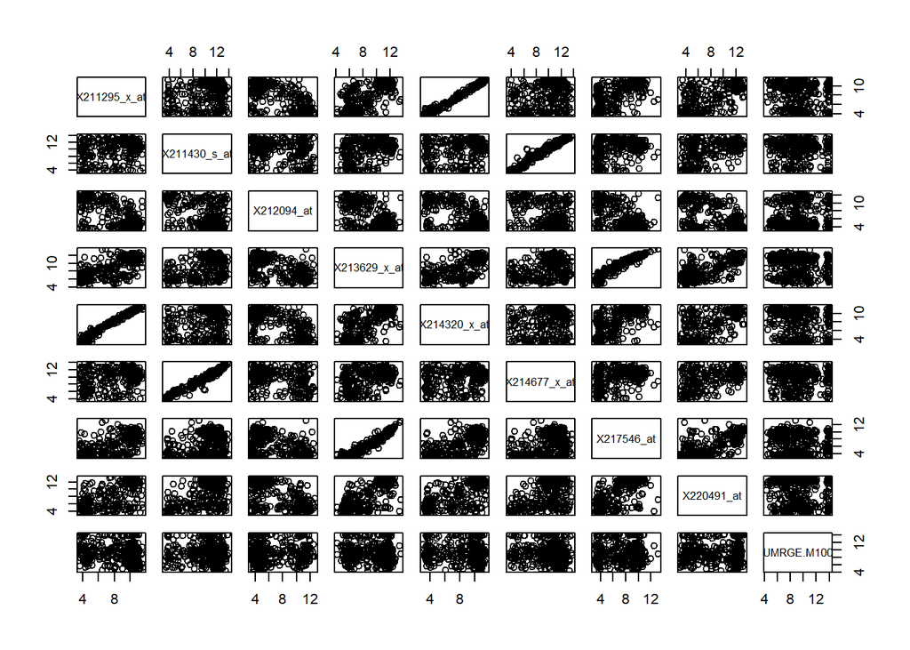

```r
pairs(mut_df[21:29])
```

Next, a logistic regression model will be created using the muatted dataset.

```r
mut_df$type = as.factor(mut_df$type)
unique(mut_df$type)
```

```
## [1] HCC    normal
## Levels: HCC normal
```

```r
model1 = glm(type~.,mut_df[-1],family=binomial())
summary(model1)
```

```
##
## Call:
## glm(formula = type ~ ., family = binomial(), data = mut_df[-1])
##
## Deviance Residuals:
##     Min       1Q   Median       3Q      Max
## -3.4674  -0.0009   0.0000   0.0599   1.2916
##
## Coefficients:
##                          Estimate Std. Error z value Pr(>|z|)
## (Intercept)             -67.34885   23.15050  -2.909  0.00362 **
## X1431_at                  1.00901    3.55887   0.284  0.77678
## X1494_f_at               -0.07619    4.01948  -0.019  0.98488
## X202409_at                0.19551    0.53187   0.368  0.71317
## X204351_at                0.14360    0.43724   0.328  0.74260
## X204694_at               -0.23320    0.59324  -0.393  0.69424
## X205695_at                1.88045    0.58578   3.210  0.00133 **
## X206024_at               -0.89567    0.68999  -1.298  0.19426
## X206239_s_at              0.20248    0.40703   0.497  0.61886
## X206354_at                0.75244    0.55247   1.362  0.17321
## X206561_s_at             -0.48420    0.33703  -1.437  0.15082
## X206727_at                1.99882    0.88110   2.269  0.02330 *
## X207201_s_at             -1.68757    0.76284  -2.212  0.02695 *
## X207608_x_at             -1.88220    0.83188  -2.263  0.02366 *
## X207609_s_at              1.77530    0.74619   2.379  0.01735 *
## X209220_at               -0.17064    0.47647  -0.358  0.72025
## X209560_s_at              0.14126    0.57874   0.244  0.80717
## X209614_at                1.95109    1.31260   1.486  0.13716
## X209976_s_at             -1.09572    3.61509  -0.303  0.76182
## X211295_x_at             -3.09062    2.50371  -1.234  0.21705
## X211430_s_at             -2.04861    1.39256  -1.471  0.14126
## X212094_at                0.49050    0.58250   0.842  0.39976
## X213629_x_at              2.31660    1.47028   1.576  0.11511
## X214320_x_at              3.82679    3.08743   1.239  0.21517
## X214677_x_at              3.50955    1.68125   2.087  0.03685 *
## X217546_at               -1.70245    1.02248  -1.665  0.09591 .
## X220491_at                0.45513    0.26067   1.746  0.08080 .
## AFFX.HUMRGE.M10098_5_at   0.11819    0.24434   0.484  0.62858
## ---
## Signif. codes:  0 '***' 0.001 '**' 0.01 '*' 0.05 '.' 0.1 ' ' 1
##
## (Dispersion parameter for binomial family taken to be 1)
##
##     Null deviance: 494.837  on 356  degrees of freedom
## Residual deviance:  45.717  on 329  degrees of freedom
## AIC: 101.72
##
## Number of Fisher Scoring iterations: 11
```

A warning was given that some fitted probabilities were very close to 0 or 1. This does not seem to be due to any particular flaws in the model, yet it seems that the chosen dataset offers the potential for very good HCC predictions.

Building a model using these chosen genes is shown to be already good (based on the residual deviance with respect to the null deviance, in addition to the AIC and Fischer scores). Yet, it can be seen from the pairs that some genes are correlated and should be dealt with. Also, the density plots show that for the 27th gene the variability is seen both in normal and HCC cases, and thus it is not a good predictor for HCC. So it is to be expected that simply removing the 27th gene and the genes showing high correlation with other genes should increase the fitness of the model, which can be reflected by the lower AIC value below.

As shown below, this can be seen to be the case. In addition, these deletions are shown to generally decrease the standard error values and increase the number of significant genes.

```r
mut_df = mut_df[-29]
mut_df = mut_df[-24]
mut_df = mut_df[-22]
mut_df = mut_df[-21]
mut_df=mut_df[-3]
mut_df$type = as.factor(mut_df$type)
model2 = glm(type~.,mut_df[-1],family=binomial())
summary(model2)
```

```
##
## Call:
## glm(formula = type ~ ., family = binomial(), data = mut_df[-1])
##
## Deviance Residuals:
##     Min       1Q   Median       3Q      Max
## -3.4350  -0.0019   0.0000   0.0548   1.3304
##
## Coefficients:
##               Estimate Std. Error z value Pr(>|z|)
## (Intercept)  -43.75720   14.44009  -3.030 0.002443 **
## X1494_f_at    -1.94803    2.75676  -0.707 0.479790
## X202409_at     0.31120    0.41733   0.746 0.455844
## X204351_at     0.10995    0.28402   0.387 0.698658
## X204694_at    -0.43633    0.46956  -0.929 0.352771
## X205695_at     1.71762    0.55122   3.116 0.001833 **
## X206024_at    -1.04968    0.55191  -1.902 0.057187 .
## X206239_s_at   0.30319    0.27478   1.103 0.269857
## X206354_at     0.87873    0.48258   1.821 0.068621 .
## X206561_s_at  -0.63841    0.28617  -2.231 0.025688 *
## X206727_at     1.34778    0.67271   2.004 0.045122 *
## X207201_s_at  -1.39107    0.55145  -2.523 0.011651 *
## X207608_x_at  -1.66815    0.62197  -2.682 0.007318 **
## X207609_s_at   1.55525    0.61268   2.538 0.011135 *
## X209220_at     0.06497    0.41185   0.158 0.874661
## X209560_s_at  -0.19225    0.39428  -0.488 0.625843
## X209614_at     2.04713    0.89864   2.278 0.022725 *
## X209976_s_at  -0.29602    0.43023  -0.688 0.491420
## X212094_at     0.20560    0.42003   0.489 0.624502
## X214320_x_at   2.97504    2.68947   1.106 0.268648
## X214677_x_at   1.21405    0.34503   3.519 0.000434 ***
## X217546_at    -0.28846    0.31970  -0.902 0.366904
## X220491_at     0.49716    0.20377   2.440 0.014693 *
## ---
## Signif. codes:  0 '***' 0.001 '**' 0.01 '*' 0.05 '.' 0.1 ' ' 1
##
## (Dispersion parameter for binomial family taken to be 1)
##
##     Null deviance: 494.837  on 356  degrees of freedom
## Residual deviance:  52.746  on 334  degrees of freedom
## AIC: 98.746
##
## Number of Fisher Scoring iterations: 10
```

The number of genes can be further reduced to only those significantly contributing to the model.

```r
model2 = glm(type~X205695_at +X207608_x_at+X206727_at+X214677_x_at+X206561_s_at+X220491_at+X209614_at+X207201_s_at+X206727_at,mut_df[-1],family=binomial())
summary(model2)
```

```
##
## Call:
## glm(formula = type ~ X205695_at + X207608_x_at + X206727_at +
##     X214677_x_at + X206561_s_at + X220491_at + X209614_at + X207201_s_at +
##     X206727_at, family = binomial(), data = mut_df[-1])
##
## Deviance Residuals:
##      Min        1Q    Median        3Q       Max
## -2.91430  -0.01894  -0.00015   0.18301   2.59388
##
## Coefficients:
##              Estimate Std. Error z value Pr(>|z|)
## (Intercept)  -26.6607     5.3997  -4.937 7.92e-07 ***
## X205695_at     0.8821     0.2526   3.493 0.000478 ***
## X207608_x_at  -0.2302     0.2141  -1.075 0.282301
## X206727_at     0.4353     0.3275   1.329 0.183828
## X214677_x_at   0.6777     0.2034   3.332 0.000861 ***
## X206561_s_at  -0.4808     0.1599  -3.006 0.002648 **
## X220491_at     0.3948     0.1472   2.682 0.007313 **
## X209614_at     1.5996     0.4278   3.739 0.000185 ***
## X207201_s_at  -0.5630     0.2642  -2.131 0.033052 *
## ---
## Signif. codes:  0 '***' 0.001 '**' 0.01 '*' 0.05 '.' 0.1 ' ' 1
##
## (Dispersion parameter for binomial family taken to be 1)
##
##     Null deviance: 494.837  on 356  degrees of freedom
## Residual deviance:  75.733  on 348  degrees of freedom
## AIC: 93.733
##
## Number of Fisher Scoring iterations: 9
```

Finally, by just following these simple steps, a very good model was built just using only 5 genes expression for HCC prediction.

```r
model3 = glm(type~X205695_at +X214677_x_at+X209614_at+X206561_s_at+X220491_at,mut_df[-1],family=binomial())
summary(model3)
```

```
##
## Call:
## glm(formula = type ~ X205695_at + X214677_x_at + X209614_at +
##     X206561_s_at + X220491_at, family = binomial(), data = mut_df[-1])
##
## Deviance Residuals:
##      Min        1Q    Median        3Q       Max
## -2.88588  -0.03672  -0.00082   0.18626   2.56960
##
## Coefficients:
##              Estimate Std. Error z value Pr(>|z|)
## (Intercept)  -21.1602     3.7695  -5.613 1.98e-08 ***
## X205695_at     0.7951     0.2355   3.377 0.000733 ***
## X214677_x_at   0.4954     0.1661   2.983 0.002853 **
## X209614_at     1.0438     0.2541   4.108 3.99e-05 ***
## X206561_s_at  -0.4597     0.1394  -3.297 0.000977 ***
## X220491_at     0.3023     0.1270   2.381 0.017276 *
## ---
## Signif. codes:  0 '***' 0.001 '**' 0.01 '*' 0.05 '.' 0.1 ' ' 1
##
## (Dispersion parameter for binomial family taken to be 1)
##
##     Null deviance: 494.837  on 356  degrees of freedom
## Residual deviance:  83.082  on 351  degrees of freedom
## AIC: 95.082
##
## Number of Fisher Scoring iterations: 8
```

Plotting the distributions of the 5 selected genes shows that they all offer relatively good seperation fo the normal cases from the HCC ones.

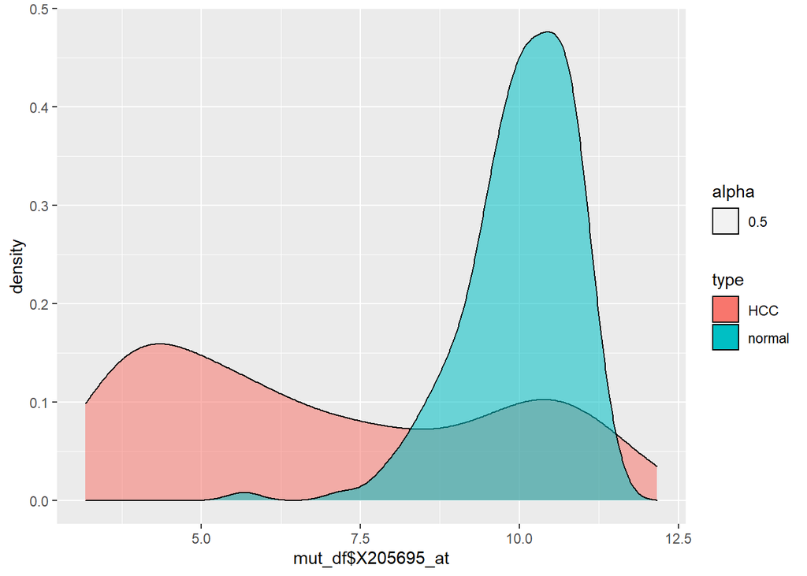

```r
mut_df %>% ggplot()+
   geom_density(aes(mut_df$X205695_at,group=type,fill=type,alpha=0.5))
```

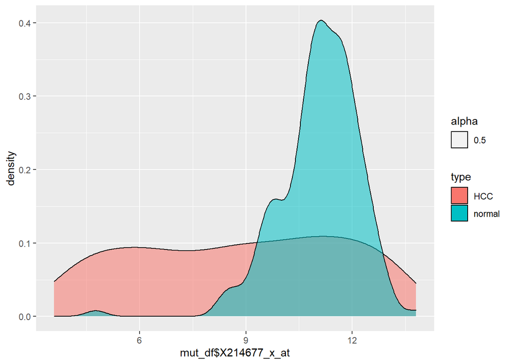

```r
mut_df %>% ggplot()+
   geom_density(aes(mut_df$X214677_x_at,group=type,fill=type,alpha=0.5))
```

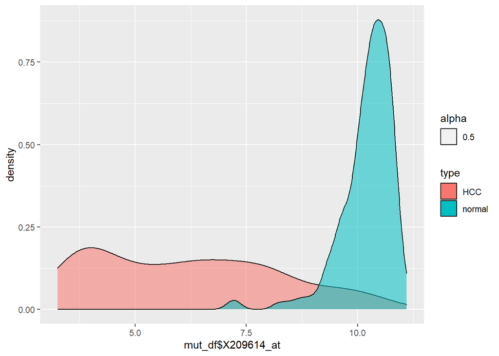

```r
mut_df %>% ggplot()+
   geom_density(aes(mut_df$X209614_at,group=type,fill=type,alpha=0.5))
```

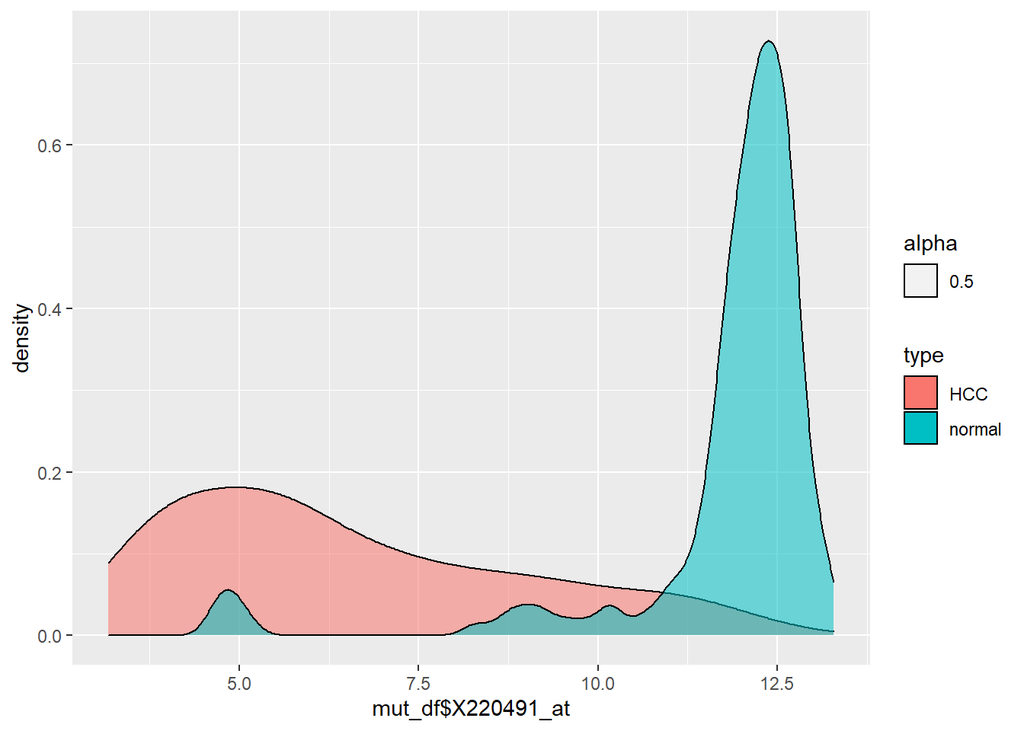

```r
mut_df %>% ggplot()+
   geom_density(aes(mut_df$X220491_at,group=type,fill=type,alpha=0.5))
```

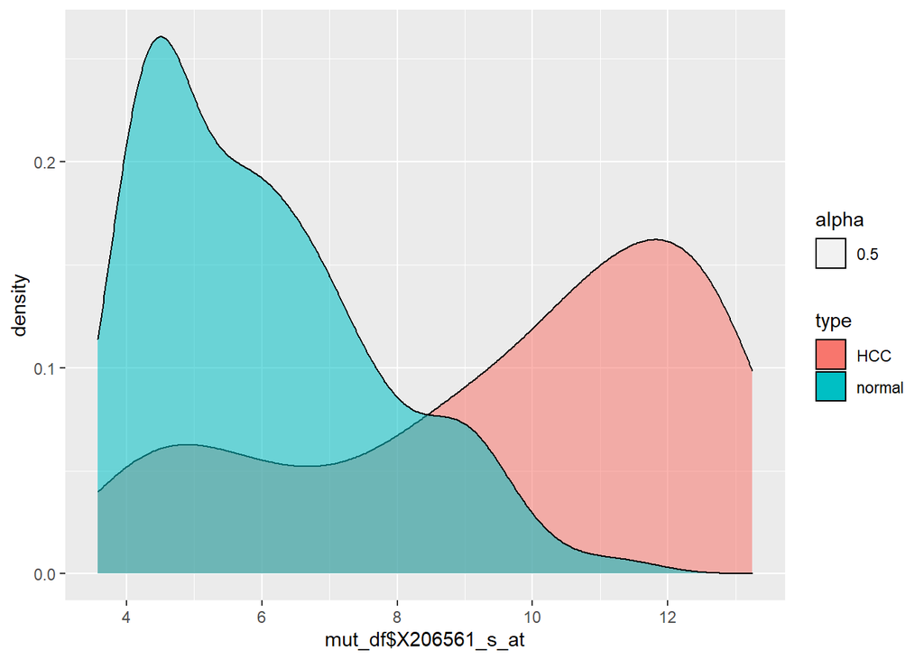

```r
mut_df %>% ggplot()+
   geom_density(aes(mut_df$X206561_s_at,group=type,fill=type,alpha=0.5))
```

```r
library(caret)
probs <- predict(model3, type = "response")
contrasts(mut_df$type)
```

```
##        normal
## HCC         0
## normal      1
```

```r
pred <- rep("HCC",nrow(mut_df))
pred[probs > 0.5] <- "normal"
t = confusionMatrix(as.factor(pred), reference=as.factor(mut_df$type))
t
```

```
## Confusion Matrix and Statistics
##
##           Reference
## Prediction HCC normal
##     HCC    174      4
##     normal   7    172
##
##                Accuracy : 0.9692
##                  95% CI : (0.9455, 0.9845)
##     No Information Rate : 0.507
##     P-Value [Acc > NIR] : <2e-16
##
##                   Kappa : 0.9384
##
##  Mcnemar's Test P-Value : 0.5465
##
##             Sensitivity : 0.9613
##             Specificity : 0.9773
##          Pos Pred Value : 0.9775
##          Neg Pred Value : 0.9609
##              Prevalence : 0.5070
##          Detection Rate : 0.4874
##    Detection Prevalence : 0.4986
##       Balanced Accuracy : 0.9693
##
##        'Positive' Class : HCC
##
```

```r
mut_df = mut_df%>%
  mutate(id=row_number())

set.seed(123,sample.kind='Rejection')

training = mut_df%>%
  slice_sample(prop=0.7)
nrow(training)
```

```
## [1] 249
```

```r
testing = anti_join(mut_df,training,by='id')
nrow(testing)
```

```
## [1] 108
```

```r
training = training%>%
  dplyr::select(-id)
testing = testing%>%
  dplyr::select(-id)

model3 = glm(type~.,training[-1],family=binomial())

probs <- predict(model3, newdata = testing,type='response')
pred <- rep("HCC",nrow(testing))
pred[probs > 0.5] <- "normal"

t = confusionMatrix(as.factor(pred), reference=as.factor(testing$type))
t
```

```
## Confusion Matrix and Statistics
##
##           Reference
## Prediction HCC normal
##     HCC     45      3
##     normal   8     52
##
##                Accuracy : 0.8981
##                  95% CI : (0.8251, 0.948)
##     No Information Rate : 0.5093
##     P-Value [Acc > NIR] : <2e-16
##
##                   Kappa : 0.7959
##
##  Mcnemar's Test P-Value : 0.2278
##
##             Sensitivity : 0.8491
##             Specificity : 0.9455
##          Pos Pred Value : 0.9375
##          Neg Pred Value : 0.8667
##              Prevalence : 0.4907
##          Detection Rate : 0.4167
##    Detection Prevalence : 0.4444
##       Balanced Accuracy : 0.8973
##
##        'Positive' Class : HCC
##
```

```r
mut_df=mut_df[-ncol(mut_df)]
```

The testing accuracy of the model is already relatively good (not deviating much from the training accuracy).

# # # # Notes before proceeding

1. It can be shown that the application of the previously considered normalization technique on the mutated dataset will not change the values distribution and will not affect the model accuracy, nor which genes are significant, but it will only change the coefficients values and make them more interpretable (related to each other meaningfully). This effect is shown only for below for 2 of the normalization techniques.

```r
mut_df_M = mut_df[1:2]
mut_df_M [3:ncol(mut_df)] = lapply(mut_df[3:ncol(mut_df)], normalize)
ncol(mut_df_M)
```

```
## [1] 24
```